# **Facial Emotion Detection**

## **Problem Definition**

**The context:** Why is this problem important to solve?  
**The objectives:** What is the intended goal?  
**The key questions:** What are the key questions that need to be answered?  
**The problem formulation:** What are we trying to solve using data science?

## **About the dataset**

The data set consists of 3 folders, i.e., 'test', 'train', and 'validation'. Each of these folders has four subfolders:

**‘happy’**: Images of people who have happy facial expressions.  
**‘sad’**: Images of people with sad or upset facial expressions.  
**‘surprise’**: Images of people who have shocked or surprised facial expressions.  
**‘neutral’**: Images of people showing no prominent emotion in their facial expression at all.

## **Mounting the Drive**

**NOTE:** Please use Google Colab from your browser for this notebook. **Google.colab is NOT a library that can be downloaded locally on your device.**

```python
# Importing the Google Drive library and mounting the drive
from google.colab import drive

# Mounting Google Drive to access the dataset and save progress
drive.mount('/content/drive')
```

## **Importing the Libraries**

```python
# Numerical and Data manipulation libraries
import numpy as np
import pandas as pd

# Visualization libraries
import matplotlib.pyplot as plt
import seaborn as sns

# Keras utilities for preprocessing images and building neural networks
from tensorflow.keras.preprocessing.image import ImageDataGenerator
from tensorflow.keras.utils import plot_model
from tensorflow.keras.models import Sequential
from tensorflow.keras.layers import Conv2D, MaxPooling2D, Flatten, Dense, Dropout, BatchNormalization

# Pre-trained models for transfer learning
from tensorflow.keras.applications import VGG16, ResNet50V2, EfficientNetB0

# For evaluation metrics
from sklearn.metrics import classification_report, confusion_matrix

# To work with file paths
import os

# Setting a theme for visualizations
sns.set_theme(style="darkgrid")
```

### **Let us load and unzip the data**

**Note:**

- You must download the dataset from the link provided on Olympus and upload the same on your Google drive before executing the code in the next cell.
- In case of any error, please make sure that the path of the file is correct as the path may be different for you.

```python
# Importing required libraries for file handling and zip extraction
import os
import zipfile

# Defining the path to the dataset zip file and the extraction directory
dataset_zip_path = '/content/drive/MyDrive/Colab Notebooks/Facial Recognition/vertopal.com_Python_Prework_ADSP+.zip'
extraction_path = '/content/Facial_Recognition_Data'

# Checking if the dataset zip file exists
if os.path.exists(dataset_zip_path):
    print("Dataset found. Extracting...")
    # Extracting the zip file to the specified directory
    with zipfile.ZipFile(dataset_zip_path, 'r') as zip_ref:
        zip_ref.extractall(extraction_path)
    print("Dataset successfully extracted to:", extraction_path)
else:
    # Error message if the dataset file is not found
    print("Error: Dataset file not found. Please check the path.")
```

```
Dataset found. Extracting...
Dataset successfully extracted to: /content/Facial_Recognition_Data
```

## **Visualizing our Classes**

Let's look at our classes.

**Write down your observation for each class. What do you think can be a unique feature of each emotion, that separates it from the remaining classes?**

### **Happy**

**Observations and Insights:__**

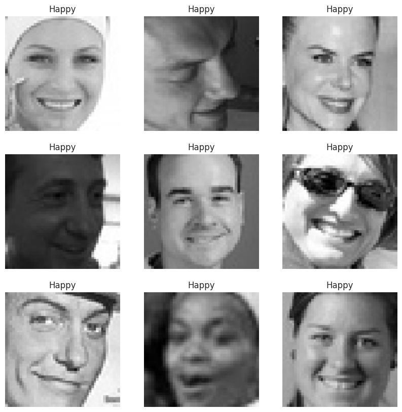

```python
# Setting the base directory path where the dataset is located
base_path = '/content/Facial_Recognition_Data/Facial_emotion_images'

# Path to the training folder and the specific "happy" class folder
train_path = os.path.join(base_path, 'train')
happy_class_path = os.path.join(train_path, 'happy')

# Checking if the "happy" folder exists
if os.path.exists(happy_class_path):
    # Listing the images in the "happy" folder
    happy_images = os.listdir(happy_class_path)

    # Displaying the first 9 images from the "happy" class
    plt.figure(figsize=(10, 10))
    for i, image_name in enumerate(happy_images[:9]):
        img_path = os.path.join(happy_class_path, image_name)  # Full path to the image
        img = load_img(img_path, target_size=(128, 128))  # Loading the image with resizing
        plt.subplot(3, 3, i + 1)
        plt.imshow(img)
        plt.title("Happy")
        plt.axis("off")  # Removing axes for cleaner display
    plt.show()
else:
    # Error message if the "happy" folder is not found
    print("Error: 'happy' folder not found")
```

Looking at these images, you can clearly see that the people are expressing happiness. The smiles are the most obvious feature, with the lips curving upward. Some of the subjects have their eyes slightly squinted, which happens naturally when you smile. Overall, their faces look relaxed and cheerful, which makes it easy to tell they're happy.

### **Sad**

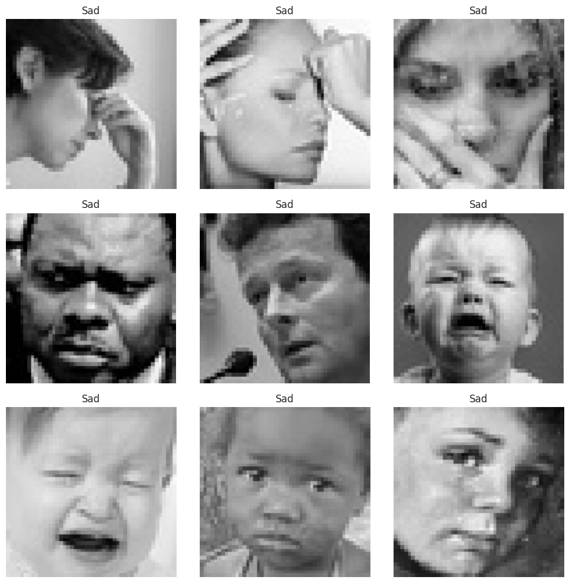

```python
# Setting the path to the "sad" class folder within the training data
sad_class_path = os.path.join(base_path, 'train', 'sad')

# Checking if the "sad" folder exists
if os.path.exists(sad_class_path):
    # Listing the images in the "sad" folder
    images = os.listdir(sad_class_path)

    # Displaying the first 9 images from the "sad" class
    plt.figure(figsize=(10, 10))
    for i, img_name in enumerate(images[:9]):
        # Load and resize each image
        img = load_img(os.path.join(sad_class_path, img_name), target_size=(128, 128))
        # Add the image to the grid
        plt.subplot(3, 3, i + 1)
        plt.imshow(img)
        plt.axis("off")  # Hiding axes for better visualization
        plt.title("Sad")
    plt.tight_layout()  # Adjust layout to prevent overlap
    plt.show()
else:
    # Raising an error if the "sad" folder is not found
    raise FileNotFoundError(f"'sad' folder not found at {sad_class_path}")
```

**Observations and Insights:__**

Looking at these images, you can immediately tell that the people are sad. Their mouths are either turned down slightly or just relaxed without any hint of a smile. The eyes often look heavy or droopy, almost like they're tired or upset. The overall expressions have this kind of subdued or tense feeling that really conveys sadness.

### **Neutral**

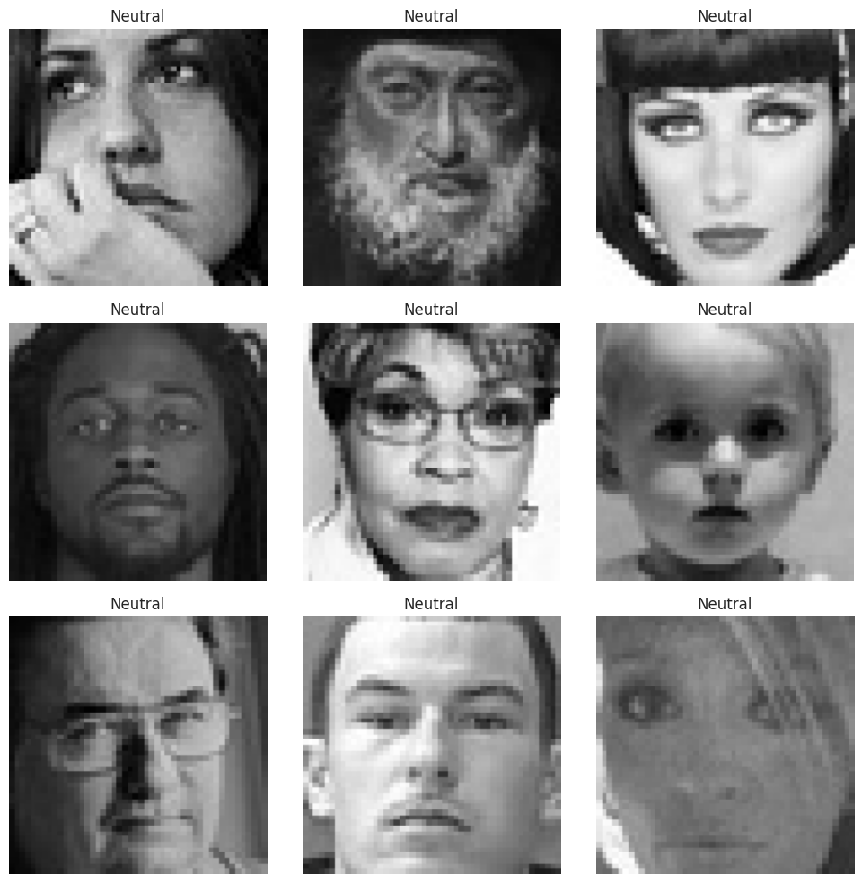

```python
# Defining the path to the "neutral" class folder in the training dataset
neutral_class_path = os.path.join(base_path, 'train', 'neutral')

# Checking if the "neutral" folder exists
if os.path.exists(neutral_class_path):
    # Getting a list of all images in the "neutral" folder
    images = os.listdir(neutral_class_path)

    # Displaying the first 9 images from the "neutral" class
    plt.figure(figsize=(10, 10))
    for i, img_name in enumerate(images[:9]):
        # Loading and resizing each image to 128x128
        img = load_img(os.path.join(neutral_class_path, img_name), target_size=(128, 128))
        # Adding each image to the grid
        plt.subplot(3, 3, i + 1)
        plt.imshow(img)
        plt.axis("off")  # Hiding axes for a clean display
        plt.title("Neutral")  # Setting the title for each image
    plt.tight_layout()  # Adjusting spacing between images
    plt.show()
else:
    # Raising an error if the "neutral" folder is missing
    raise FileNotFoundError(f"'neutral' folder not found at {neutral_class_path}")
```

**Observations and Insights:__**

Looking at these neutral faces, there's not much emotion coming through. The expressions are pretty blank—mouths are straight, eyes don’t give away anything, and there’s this overall calmness. It’s like the people are just sitting there without reacting to anything, which makes sense for a neutral expression.

### **Surprised**

[figure not shown]

```python
# Setting the path to the "surprise" class folder in the training dataset
surprised_class_path = os.path.join(base_path, 'train', 'surprise')

# Checking if the "surprise" folder exists
if os.path.exists(surprised_class_path):
    # Getting a list of images in the "surprise" folder
    images = os.listdir(surprised_class_path)

    # Displaying the first 9 images from the "surprise" class
    plt.figure(figsize=(10, 10))
    for i, img_name in enumerate(images[:9]):
        # Loading and resizing each image to 128x128
        img = load_img(os.path.join(surprised_class_path, img_name), target_size=(128, 128))
        # Adding the image to a 3x3 grid
        plt.subplot(3, 3, i + 1)
        plt.imshow(img)
        plt.axis("off")  # Hiding axes for a clean display
        plt.title("Surprised")  # Setting the title for each image
    plt.tight_layout()  # Adjusting layout to prevent overlap
    plt.show()
else:
    # Raising an error if the "surprise" folder is missing
    raise FileNotFoundError(f"'surprise' folder not found at {surprised_class_path}")
```

**Observations and Insights:__**

Looking at these faces, you can tell they’re all caught off guard or startled. The wide-open eyes are the first thing you notice, and many of them have their mouths open as if they just gasped. Some even have their hands on their faces, adding to the dramatic reaction. It’s the kind of expression you’d make when something totally unexpected happens.

## **Checking Distribution of Classes**

```python
# Defining the dataset splits and class names to analyze distribution
data_splits = ['train', 'test', 'validation']  # Data is split into these subsets
class_names = ['happy', 'neutral', 'sad', 'surprise']  # Emotion categories

# Function to check and print the distribution of images across splits and classes
def check_class_distribution(base_path, splits, classes):
    for split in splits:  # Looping through each data split
        print(f"Distribution in '{split}' folder:")
        split_path = os.path.join(base_path, split)  # Path to the current split folder
        if os.path.exists(split_path):  # Check if the split folder exists
            for cls in classes:  # Loop through each class
                class_path = os.path.join(split_path, cls)  # Path to the specific class folder
                if os.path.exists(class_path):  # Check if the class folder exists
                    count = len(os.listdir(class_path))  # Count the images in the folder
                    print(f"  {cls.capitalize()}: {count} images")  # Print the count for the class
                else:
                    # Print a message if the class folder is missing
                    print(f"  {cls.capitalize()}: Folder not found!")
        else:
            # Print a message if the split folder is missing
            print(f"'{split}' folder not found!")
        print()  # Add a blank line for readability

# Calling the function to check the class distribution
check_class_distribution(base_path, data_splits, class_names)
```

```
Distribution in 'train' folder:
  Happy: 3976 images
  Neutral: 3978 images
  Sad: 3982 images
  Surprise: 3173 images

Distribution in 'test' folder:
  Happy: 32 images
  Neutral: 32 images
  Sad: 32 images
  Surprise: 32 images

Distribution in 'validation' folder:
  Happy: 1825 images
  Neutral: 1216 images
  Sad: 1139 images
  Surprise: 797 images
```

**Observations and Insights:__**

Looking at the distribution, the training dataset is relatively balanced across the "happy," "neutral," and "sad" classes, but the "surprise" class has significantly fewer images (3173 compared to ~3980 for the others). The test set is perfectly balanced with 32 images per class, which is good for evaluation. However, in the validation set, there’s a clear imbalance: "happy" has the most images (1825), while "surprise" has the fewest (797).

**Think About It:**

- Are the classes equally distributed? If not, do you think the imbalance is too high? Will it be a problem as we progress?
- Are there any Exploratory Data Analysis tasks that we can do here? Would they provide any meaningful insights?

The imbalance in the training and validation sets might cause the model to struggle with the "surprise" class since it has fewer examples to learn from. This could lead to lower accuracy or recall for that class. To address this, we might consider applying data augmentation to "surprise" images in the training and validation sets to artificially increase their representation.

For EDA, we could create bar plots of the class distributions for each split to visualize the imbalance more clearly. It would also be helpful to check if the smaller classes have unique patterns that could affect the model’s ability to generalize. If needed, techniques like oversampling, undersampling, or class weighting in the loss function might help mitigate the effects of this imbalance.

## **Creating our Data Loaders**

In this section, we are creating data loaders that we will use as inputs to our Neural Network.

**You have two options for the color_mode. You can set it to color_mode = 'rgb' or color_mode = 'grayscale'. You will need to try out both and see for yourself which one gives better performance.**

```python
from tensorflow.keras.preprocessing.image import ImageDataGenerator

train_dir = os.path.join(base_path, 'train')
test_dir = os.path.join(base_path, 'test')
val_dir = os.path.join(base_path, 'validation')

train_datagen = ImageDataGenerator(
    rescale=1.0/255,
    rotation_range=20,
    width_shift_range=0.2,
    height_shift_range=0.2,
    shear_range=0.2,
    zoom_range=0.2,
    horizontal_flip=True,
    fill_mode='nearest'
)

val_test_datagen = ImageDataGenerator(rescale=1.0/255)

def create_data_loaders(color_mode):
    print(f"Creating data loaders with color_mode='{color_mode}'...")
    # Training set
    train_generator = train_datagen.flow_from_directory(
        train_dir,
        target_size=(128, 128),
        batch_size=32,
        class_mode='categorical',
        color_mode=color_mode
    )

    # Validation set
    val_generator = val_test_datagen.flow_from_directory(
        val_dir,
        target_size=(128, 128),
        batch_size=32,
        class_mode='categorical',
        color_mode=color_mode
    )

    # Test set
    test_generator = val_test_datagen.flow_from_directory(
        test_dir,
        target_size=(128, 128),
        batch_size=32,
        class_mode='categorical',
        color_mode=color_mode
    )
    return train_generator, val_generator, test_generator

# Example: Using grayscale mode (can change to 'rgb')
train_gen, val_gen, test_gen = create_data_loaders(color_mode='grayscale')
```

```
Creating data loaders with color_mode='grayscale'...
Found 15109 images belonging to 4 classes.
Found 4977 images belonging to 4 classes.
Found 128 images belonging to 4 classes.
```

## **Model Building**

**Think About It:**

- Are Convolutional Neural Networks the right approach? Should we have gone with Artificial Neural Networks instead?
- What are the advantages of CNNs over ANNs and are they applicable here?

When it comes to image data like this, CNNs are definitely the right choice. Unlike ANN, CNNs are specifically designed to handle the spatial structure of images. They can capture patterns like edges, textures, and shapes using convolutional layers, which makes them way better at understanding visual data.

If we had used ANNs, we’d have to flatten the images into 1D arrays, losing all that spatial information. ANNs would treat every pixel as independent, which isn’t ideal because pixels close to each other often hold related information in an image.

So yes, CNNs are a much better fit for this kind of task since they’re not only more efficient but also more effective at extracting features from images in a meaningful way.

### **Creating the Base Neural Network**

```python
# Importing necessary modules for building a Convolutional Neural Network
from tensorflow.keras.models import Sequential
from tensorflow.keras.layers import Conv2D, MaxPooling2D, Flatten, Dense, Dropout, BatchNormalization

# Function to define the base CNN model architecture
def create_base_cnn(input_shape=(128, 128, 1)):
    model = Sequential()

    # First convolutional layer with batch normalization and max pooling
    model.add(Conv2D(32, (3, 3), activation='relu', input_shape=input_shape))
    model.add(BatchNormalization())
    model.add(MaxPooling2D(pool_size=(2, 2)))

    # Second convolutional layer with batch normalization and max pooling
    model.add(Conv2D(64, (3, 3), activation='relu'))
    model.add(BatchNormalization())
    model.add(MaxPooling2D(pool_size=(2, 2)))

    # Third convolutional layer with batch normalization and max pooling
    model.add(Conv2D(128, (3, 3), activation='relu'))
    model.add(BatchNormalization())
    model.add(MaxPooling2D(pool_size=(2, 2)))

    # Flattening the feature maps into a single vector
    model.add(Flatten())

    # Fully connected dense layer with dropout for regularization
    model.add(Dense(128, activation='relu'))
    model.add(Dropout(0.5))

    # Output layer with 4 units for the 4 classes (happy, neutral, sad, surprise)
    model.add(Dense(4, activation='softmax'))

    return model

# Defining the input shape as (128, 128, 1) for grayscale images
input_shape = (128, 128, 1)

# Creating the base CNN model using the defined function
base_cnn = create_base_cnn(input_shape)

# Displaying the model architecture summary
base_cnn.summary()
```

```
Model: "sequential_2"
```

```
┏━━━━━━━━━━━━━━━━━━━━━━━━━━━━━━━━━━━━━━┳━━━━━━━━━━━━━━━━━━━━━━━━━━━━━┳━━━━━━━━━━━━━━━━━┓
┃ Layer (type)                         ┃ Output Shape                ┃         Param # ┃
┡━━━━━━━━━━━━━━━━━━━━━━━━━━━━━━━━━━━━━━╇━━━━━━━━━━━━━━━━━━━━━━━━━━━━━╇━━━━━━━━━━━━━━━━━┩
│ conv2d_7 (Conv2D)                    │ (None, 126, 126, 32)        │             320 │
├──────────────────────────────────────┼─────────────────────────────┼─────────────────┤
│ batch_normalization_7                │ (None, 126, 126, 32)        │             128 │
│ (BatchNormalization)                 │                             │                 │
├──────────────────────────────────────┼─────────────────────────────┼─────────────────┤
│ max_pooling2d_7 (MaxPooling2D)       │ (None, 63, 63, 32)          │               0 │
├──────────────────────────────────────┼─────────────────────────────┼─────────────────┤
│ conv2d_8 (Conv2D)                    │ (None, 61, 61, 64)          │          18,496 │
├──────────────────────────────────────┼─────────────────────────────┼─────────────────┤
│ batch_normalization_8                │ (None, 61, 61, 64)          │             256 │
│ (BatchNormalization)                 │                             │                 │
├──────────────────────────────────────┼─────────────────────────────┼─────────────────┤
│ max_pooling2d_8 (MaxPooling2D)       │ (None, 30, 30, 64)          │               0 │
├──────────────────────────────────────┼─────────────────────────────┼─────────────────┤
│ conv2d_9 (Conv2D)                    │ (None, 28, 28, 128)         │          73,856 │
├──────────────────────────────────────┼─────────────────────────────┼─────────────────┤
│ batch_normalization_9                │ (None, 28, 28, 128)         │             512 │
│ (BatchNormalization)                 │                             │                 │
├──────────────────────────────────────┼─────────────────────────────┼─────────────────┤
│ max_pooling2d_9 (MaxPooling2D)       │ (None, 14, 14, 128)         │               0 │
├──────────────────────────────────────┼─────────────────────────────┼─────────────────┤
│ flatten_4 (Flatten)                  │ (None, 25088)               │               0 │
├──────────────────────────────────────┼─────────────────────────────┼─────────────────┤
│ dense_11 (Dense)                     │ (None, 128)                 │       3,211,392 │
├──────────────────────────────────────┼─────────────────────────────┼─────────────────┤
│ dropout_7 (Dropout)                  │ (None, 128)                 │               0 │
├──────────────────────────────────────┼─────────────────────────────┼─────────────────┤
│ dense_12 (Dense)                     │ (None, 4)                   │             516 │
└──────────────────────────────────────┴─────────────────────────────┴─────────────────┘
```

```
 Total params: 3,305,476 (12.61 MB)
```

```
 Trainable params: 3,305,028 (12.61 MB)
```

```
 Non-trainable params: 448 (1.75 KB)
```

### **Compiling and Training the Model**

```python
# Importing the Adam optimizer
from tensorflow.keras.optimizers import Adam

# Function to compile and train the CNN model
def compile_and_train_model(model, train_gen, val_gen, epochs=20, batch_size=32):
    # Compiling the model with Adam optimizer, categorical crossentropy loss, and accuracy as the metric
    model.compile(
        optimizer=Adam(learning_rate=0.001),  # Adaptive learning rate optimizer
        loss='categorical_crossentropy',     # Loss function for multi-class classification
        metrics=['accuracy']                 # Metric to monitor during training
    )

    # Training the model on the training data and validating on the validation data
    history = model.fit(
        train_gen,                           # Training data generator
        steps_per_epoch=train_gen.samples // batch_size,  # Number of training steps per epoch
        validation_data=val_gen,             # Validation data generator
        validation_steps=val_gen.samples // batch_size,  # Number of validation steps per epoch
        epochs=epochs,                       # Number of training epochs
        verbose=1                            # Display training progress
    )
    return history

# Training the base CNN model using the defined function
history = compile_and_train_model(base_cnn, train_gen, val_gen, epochs=20, batch_size=32)
```

```
472/472 ━━━━━━━━━━━━━━━━━━━━ 156s 326ms/step - accuracy: 0.2685 - loss: 2.0244 - val_accuracy: 0.2335 - val_loss: 7.7283
472/472 ━━━━━━━━━━━━━━━━━━━━ 0s 125us/step - accuracy: 0.2188 - loss: 1.7585 - val_accuracy: 0.1765 - val_loss: 8.6037
472/472 ━━━━━━━━━━━━━━━━━━━━ 156s 330ms/step - accuracy: 0.2578 - loss: 1.3833 - val_accuracy: 0.2284 - val_loss: 1.3722
472/472 ━━━━━━━━━━━━━━━━━━━━ 0s 99us/step - accuracy: 0.3750 - loss: 1.3638 - val_accuracy: 0.3529 - val_loss: 1.3625
472/472 ━━━━━━━━━━━━━━━━━━━━ 155s 328ms/step - accuracy: 0.2648 - loss: 1.3830 - val_accuracy: 0.3669 - val_loss: 1.3689
472/472 ━━━━━━━━━━━━━━━━━━━━ 0s 89us/step - accuracy: 0.1875 - loss: 1.3920 - val_accuracy: 0.2941 - val_loss: 1.3880
472/472 ━━━━━━━━━━━━━━━━━━━━ 160s 339ms/step - accuracy: 0.2628 - loss: 1.3816 - val_accuracy: 0.2446 - val_loss: 1.3708
472/472 ━━━━━━━━━━━━━━━━━━━━ 0s 101us/step - accuracy: 0.3125 - loss: 1.3559 - val_accuracy: 0.1176 - val_loss: 1.4139
472/472 ━━━━━━━━━━━━━━━━━━━━ 159s 337ms/step - accuracy: 0.2646 - loss: 1.3823 - val_accuracy: 0.2446 - val_loss: 1.3701
472/472 ━━━━━━━━━━━━━━━━━━━━ 0s 126us/step - accuracy: 0.2500 - loss: 1.4056 - val_accuracy: 0.1176 - val_loss: 1.4022
472/472 ━━━━━━━━━━━━━━━━━━━━ 164s 347ms/step - accuracy: 0.2593 - loss: 1.3829 - val_accuracy: 0.2440 - val_loss: 1.3703
472/472 ━━━━━━━━━━━━━━━━━━━━ 0s 101us/step - accuracy: 0.3750 - loss: 1.3616 - val_accuracy: 0.2941 - val_loss: 1.3617
472/472 ━━━━━━━━━━━━━━━━━━━━ 161s 341ms/step - accuracy: 0.2616 - loss: 1.3821 - val_accuracy: 0.2442 - val_loss: 1.3716
472/472 ━━━━━━━━━━━━━━━━━━━━ 0s 107us/step - accuracy: 0.3438 - loss: 1.3486 - val_accuracy: 0.2353 - val_loss: 1.3877
472/472 ━━━━━━━━━━━━━━━━━━━━ 154s 325ms/step - accuracy: 0.2546 - loss: 1.3816 - val_accuracy: 0.2440 - val_loss: 1.3711
472/472 ━━━━━━━━━━━━━━━━━━━━ 0s 90us/step - accuracy: 0.2188 - loss: 1.3839 - val_accuracy: 0.2941 - val_loss: 1.3613
472/472 ━━━━━━━━━━━━━━━━━━━━ 152s 321ms/step - accuracy: 0.2533 - loss: 1.3828 - val_accuracy: 0.3665 - val_loss: 1.3696
472/472 ━━━━━━━━━━━━━━━━━━━━ 0s 99us/step - accuracy: 0.4062 - loss: 1.3899 - val_accuracy: 0.4118 - val_loss: 1.3594
472/472 ━━━━━━━━━━━━━━━━━━━━ 152s 322ms/step - accuracy: 0.2645 - loss: 1.5289 - val_accuracy: 0.2873 - val_loss: 2.2300
472/472 ━━━━━━━━━━━━━━━━━━━━ 0s 107us/step - accuracy: 0.3438 - loss: 1.3266 - val_accuracy: 0.2941 - val_loss: 3.0008
```

### **Evaluating the Model on the Test Set**

```python
# Evaluating the trained model on the test data to check its performance
test_loss, test_accuracy = base_cnn.evaluate(
    test_gen,                                   # Test data generator
    steps=test_gen.samples // test_gen.batch_size,  # Number of steps for evaluation
    verbose=1                                  # Display progress during evaluation
)

# Printing the loss and accuracy of the model on the test set
print(f"Test Loss: {test_loss:.4f}")  # Displaying the test loss rounded to 4 decimal places
print(f"Test Accuracy: {test_accuracy * 100:.2f}%")  # Displaying the test accuracy as a percentage
```

```
4/4 ━━━━━━━━━━━━━━━━━━━━ 0s 60ms/step - accuracy: 0.2188 - loss: 2.0674
Test Loss: 2.1040
Test Accuracy: 22.66%
```

**Observations and Insights:__**

### **Creating the second Convolutional Neural Network**

- Try out a slightly larger architecture

```python
# Importing required modules for building the CNN model
from tensorflow.keras.models import Sequential
from tensorflow.keras.layers import Conv2D, MaxPooling2D, Flatten, Dense, Dropout, BatchNormalization

# Function to define a larger CNN architecture
def create_larger_cnn(input_shape=(128, 128, 1)):
    model = Sequential()

    # First convolutional block: Conv2D -> BatchNormalization -> MaxPooling
    model.add(Conv2D(32, (3, 3), activation='relu', input_shape=input_shape))
    model.add(BatchNormalization())
    model.add(MaxPooling2D(pool_size=(2, 2)))

    # Second convolutional block: Conv2D -> BatchNormalization -> MaxPooling
    model.add(Conv2D(64, (3, 3), activation='relu'))
    model.add(BatchNormalization())
    model.add(MaxPooling2D(pool_size=(2, 2)))

    # Third convolutional block: Conv2D -> BatchNormalization -> MaxPooling
    model.add(Conv2D(128, (3, 3), activation='relu'))
    model.add(BatchNormalization())
    model.add(MaxPooling2D(pool_size=(2, 2)))

    # Fourth convolutional block: Conv2D -> BatchNormalization -> MaxPooling
    model.add(Conv2D(256, (3, 3), activation='relu'))
    model.add(BatchNormalization())
    model.add(MaxPooling2D(pool_size=(2, 2)))

    # Flatten the feature maps to feed into fully connected layers
    model.add(Flatten())

    # Fully connected layer with 256 neurons and dropout for regularization
    model.add(Dense(256, activation='relu'))
    model.add(Dropout(0.5))

    # Fully connected layer with 128 neurons and dropout for regularization
    model.add(Dense(128, activation='relu'))
    model.add(Dropout(0.5))

    # Output layer with 4 units for the 4 classes, using softmax activation
    model.add(Dense(4, activation='softmax'))

    return model

# Defining the input shape for grayscale images
input_shape = (128, 128, 1)

# Creating the larger CNN model using the defined function
larger_cnn = create_larger_cnn(input_shape)

# Displaying the model architecture summary
larger_cnn.summary()
```

```
Model: "sequential_3"
```

```
┏━━━━━━━━━━━━━━━━━━━━━━━━━━━━━━━━━━━━━━┳━━━━━━━━━━━━━━━━━━━━━━━━━━━━━┳━━━━━━━━━━━━━━━━━┓
┃ Layer (type)                         ┃ Output Shape                ┃         Param # ┃
┡━━━━━━━━━━━━━━━━━━━━━━━━━━━━━━━━━━━━━━╇━━━━━━━━━━━━━━━━━━━━━━━━━━━━━╇━━━━━━━━━━━━━━━━━┩
│ conv2d_10 (Conv2D)                   │ (None, 126, 126, 32)        │             320 │
├──────────────────────────────────────┼─────────────────────────────┼─────────────────┤
│ batch_normalization_10               │ (None, 126, 126, 32)        │             128 │
│ (BatchNormalization)                 │                             │                 │
├──────────────────────────────────────┼─────────────────────────────┼─────────────────┤
│ max_pooling2d_10 (MaxPooling2D)      │ (None, 63, 63, 32)          │               0 │
├──────────────────────────────────────┼─────────────────────────────┼─────────────────┤
│ conv2d_11 (Conv2D)                   │ (None, 61, 61, 64)          │          18,496 │
├──────────────────────────────────────┼─────────────────────────────┼─────────────────┤
│ batch_normalization_11               │ (None, 61, 61, 64)          │             256 │
│ (BatchNormalization)                 │                             │                 │
├──────────────────────────────────────┼─────────────────────────────┼─────────────────┤
│ max_pooling2d_11 (MaxPooling2D)      │ (None, 30, 30, 64)          │               0 │
├──────────────────────────────────────┼─────────────────────────────┼─────────────────┤
│ conv2d_12 (Conv2D)                   │ (None, 28, 28, 128)         │          73,856 │
├──────────────────────────────────────┼─────────────────────────────┼─────────────────┤
│ batch_normalization_12               │ (None, 28, 28, 128)         │             512 │
│ (BatchNormalization)                 │                             │                 │
├──────────────────────────────────────┼─────────────────────────────┼─────────────────┤
│ max_pooling2d_12 (MaxPooling2D)      │ (None, 14, 14, 128)         │               0 │
├──────────────────────────────────────┼─────────────────────────────┼─────────────────┤
│ conv2d_13 (Conv2D)                   │ (None, 12, 12, 256)         │         295,168 │
├──────────────────────────────────────┼─────────────────────────────┼─────────────────┤
│ batch_normalization_13               │ (None, 12, 12, 256)         │           1,024 │
│ (BatchNormalization)                 │                             │                 │
├──────────────────────────────────────┼─────────────────────────────┼─────────────────┤
│ max_pooling2d_13 (MaxPooling2D)      │ (None, 6, 6, 256)           │               0 │
├──────────────────────────────────────┼─────────────────────────────┼─────────────────┤
│ flatten_5 (Flatten)                  │ (None, 9216)                │               0 │
├──────────────────────────────────────┼─────────────────────────────┼─────────────────┤
│ dense_13 (Dense)                     │ (None, 256)                 │       2,359,552 │
├──────────────────────────────────────┼─────────────────────────────┼─────────────────┤
│ dropout_8 (Dropout)                  │ (None, 256)                 │               0 │
├──────────────────────────────────────┼─────────────────────────────┼─────────────────┤
│ dense_14 (Dense)                     │ (None, 128)                 │          32,896 │
├──────────────────────────────────────┼─────────────────────────────┼─────────────────┤
│ dropout_9 (Dropout)                  │ (None, 128)                 │               0 │
├──────────────────────────────────────┼─────────────────────────────┼─────────────────┤
│ dense_15 (Dense)                     │ (None, 4)                   │             516 │
└──────────────────────────────────────┴─────────────────────────────┴─────────────────┘
```

```
 Total params: 2,782,724 (10.62 MB)
```

```
 Trainable params: 2,781,764 (10.61 MB)
```

```
 Non-trainable params: 960 (3.75 KB)
```

### **Compiling and Training the Model**

```python
# Compiling the larger CNN model
# Using Adam optimizer for adaptive learning, categorical crossentropy for multi-class classification,
# and accuracy as the metric to evaluate the model's performance during training
larger_cnn.compile(
    optimizer='adam',                  # Adaptive optimizer
    loss='categorical_crossentropy',   # Loss function for multi-class classification
    metrics=['accuracy']               # Evaluation metric
)

# Training the larger CNN model
# Feeding the model with the training data, validating on the validation set,
# and running the training for 25 epochs
history = larger_cnn.fit(
    train_gen,                          # Training data generator
    steps_per_epoch=train_gen.samples // train_gen.batch_size,  # Number of steps per epoch
    validation_data=val_gen,            # Validation data generator
    validation_steps=val_gen.samples // val_gen.batch_size,  # Number of validation steps per epoch
    epochs=25                           # Number of epochs for training
)
```

```
472/472 ━━━━━━━━━━━━━━━━━━━━ 168s 351ms/step - accuracy: 0.2661 - loss: 2.6643 - val_accuracy: 0.3026 - val_loss: 1.3598
472/472 ━━━━━━━━━━━━━━━━━━━━ 0s 131us/step - accuracy: 0.2812 - loss: 1.3903 - val_accuracy: 0.2941 - val_loss: 1.3658
472/472 ━━━━━━━━━━━━━━━━━━━━ 169s 357ms/step - accuracy: 0.2569 - loss: 1.3885 - val_accuracy: 0.2831 - val_loss: 1.3682
472/472 ━━━━━━━━━━━━━━━━━━━━ 0s 108us/step - accuracy: 0.2188 - loss: 1.3725 - val_accuracy: 0.3529 - val_loss: 1.3767
472/472 ━━━━━━━━━━━━━━━━━━━━ 168s 354ms/step - accuracy: 0.2645 - loss: 1.3826 - val_accuracy: 0.2444 - val_loss: 1.3712
472/472 ━━━━━━━━━━━━━━━━━━━━ 0s 100us/step - accuracy: 0.2812 - loss: 1.3831 - val_accuracy: 0.1765 - val_loss: 1.3625
472/472 ━━━━━━━━━━━━━━━━━━━━ 166s 352ms/step - accuracy: 0.2676 - loss: 1.3830 - val_accuracy: 0.2446 - val_loss: 1.3709
472/472 ━━━━━━━━━━━━━━━━━━━━ 0s 114us/step - accuracy: 0.2812 - loss: 1.3959 - val_accuracy: 0.1176 - val_loss: 1.3622
472/472 ━━━━━━━━━━━━━━━━━━━━ 165s 350ms/step - accuracy: 0.2645 - loss: 1.3845 - val_accuracy: 0.2302 - val_loss: 1.3711
472/472 ━━━━━━━━━━━━━━━━━━━━ 0s 102us/step - accuracy: 0.1875 - loss: 1.3773 - val_accuracy: 0.1765 - val_loss: 1.3760
472/472 ━━━━━━━━━━━━━━━━━━━━ 168s 355ms/step - accuracy: 0.2612 - loss: 1.3884 - val_accuracy: 0.2476 - val_loss: 1.6836
472/472 ━━━━━━━━━━━━━━━━━━━━ 0s 98us/step - accuracy: 0.2812 - loss: 1.5859 - val_accuracy: 0.1765 - val_loss: 1.4237
472/472 ━━━━━━━━━━━━━━━━━━━━ 165s 348ms/step - accuracy: 0.2688 - loss: 1.3847 - val_accuracy: 0.2292 - val_loss: 1.3709
472/472 ━━━━━━━━━━━━━━━━━━━━ 0s 104us/step - accuracy: 0.2812 - loss: 1.3696 - val_accuracy: 0.1176 - val_loss: 1.3748
472/472 ━━━━━━━━━━━━━━━━━━━━ 164s 346ms/step - accuracy: 0.2590 - loss: 1.3814 - val_accuracy: 0.3669 - val_loss: 1.3701
472/472 ━━━━━━━━━━━━━━━━━━━━ 0s 111us/step - accuracy: 0.2812 - loss: 1.4042 - val_accuracy: 0.2941 - val_loss: 1.4004
472/472 ━━━━━━━━━━━━━━━━━━━━ 164s 347ms/step - accuracy: 0.2685 - loss: 1.3812 - val_accuracy: 0.2288 - val_loss: 1.3713
472/472 ━━━━━━━━━━━━━━━━━━━━ 0s 114us/step - accuracy: 0.1562 - loss: 1.4190 - val_accuracy: 0.2941 - val_loss: 1.3617
472/472 ━━━━━━━━━━━━━━━━━━━━ 164s 347ms/step - accuracy: 0.2546 - loss: 1.3833 - val_accuracy: 0.2286 - val_loss: 1.3709
472/472 ━━━━━━━━━━━━━━━━━━━━ 0s 127us/step - accuracy: 0.3125 - loss: 1.3763 - val_accuracy: 0.2941 - val_loss: 1.3608
472/472 ━━━━━━━━━━━━━━━━━━━━ 168s 355ms/step - accuracy: 0.2658 - loss: 1.3809 - val_accuracy: 0.2450 - val_loss: 1.3713
472/472 ━━━━━━━━━━━━━━━━━━━━ 0s 118us/step - accuracy: 0.4062 - loss: 1.3752 - val_accuracy: 0.0588 - val_loss: 1.3515
472/472 ━━━━━━━━━━━━━━━━━━━━ 167s 353ms/step - accuracy: 0.2541 - loss: 1.3818 - val_accuracy: 0.2450 - val_loss: 1.3712
472/472 ━━━━━━━━━━━━━━━━━━━━ 0s 100us/step - accuracy: 0.1250 - loss: 1.3918 - val_accuracy: 0.0588 - val_loss: 1.4139
472/472 ━━━━━━━━━━━━━━━━━━━━ 163s 345ms/step - accuracy: 0.2648 - loss: 1.3818 - val_accuracy: 0.2286 - val_loss: 1.3714
```

### **Evaluating the Model on the Test Set**

```python
# Evaluating the larger CNN model on the test data
# This checks how well the model performs on unseen data
test_loss, test_accuracy = larger_cnn.evaluate(
    test_gen,                                    # Test data generator
    steps=test_gen.samples // test_gen.batch_size  # Number of steps for evaluation
)

# Printing the test accuracy as a percentage to summarize the model's performance
print(f"Test Accuracy: {test_accuracy * 100:.2f}%")
```

```
4/4 ━━━━━━━━━━━━━━━━━━━━ 0s 70ms/step - accuracy: 0.2552 - loss: 1.3882
Test Accuracy: 25.00%
```

**Observations and Insights:__**

The results indicate that the larger CNN architecture is still struggling to learn meaningful patterns from the data. The training and validation accuracy remain low throughout the epochs, showing limited improvement, while the loss values fluctuate without significant decline. The test accuracy of 25% confirms that the model has poor generalization ability and is likely not capturing the complexity of the task.

## **Think About It:**

- Did the models have a satisfactory performance? If not, then what are the possible reasons?
- Which Color mode showed better overall performance? What are the possible reasons? Do you think having 'rgb' color mode is needed because the images are already black and white?

## **Transfer Learning Architectures**

In this section, we will create several Transfer Learning architectures. For the pre-trained models, we will select three popular architectures namely, VGG16, ResNet v2, and Efficient Net. The difference between these architectures and the previous architectures is that these will require 3 input channels while the earlier ones worked on 'grayscale' images. Therefore, we need to create new DataLoaders.

### **Creating our Data Loaders for Transfer Learning Architectures**

In this section, we are creating data loaders that we will use as inputs to our Neural Network. We will have to go with color_mode = 'rgb' as this is the required format for the transfer learning architectures.

```python
# Importing ImageDataGenerator for data augmentation and preprocessing
from tensorflow.keras.preprocessing.image import ImageDataGenerator

# Setting up paths to the train, test, and validation directories
train_dir = os.path.join(base_path, 'train')
test_dir = os.path.join(base_path, 'test')
val_dir = os.path.join(base_path, 'validation')

# Creating a data generator for the training set with augmentation
# Augmentation includes rescaling and various transformations to increase data variability
train_datagen = ImageDataGenerator(
    rescale=1.0/255,          # Normalize pixel values to the range [0, 1]
    rotation_range=20,        # Randomly rotate images
    width_shift_range=0.2,    # Randomly shift images horizontally
    height_shift_range=0.2,   # Randomly shift images vertically
    shear_range=0.2,          # Randomly apply shearing transformations
    zoom_range=0.2,           # Randomly zoom into images
    horizontal_flip=True,     # Randomly flip images horizontally
    fill_mode='nearest'       # Fill missing pixels after transformations
)

# Creating a data generator for validation and test sets without augmentation (just rescaling)
val_test_datagen = ImageDataGenerator(rescale=1.0/255)

# Preparing the training data generator for RGB images with categorical class labels
train_gen_rgb = train_datagen.flow_from_directory(
    train_dir,               # Path to the training data
    target_size=(224, 224),  # Resize images to 224x224 pixels
    batch_size=32,           # Number of images per batch
    class_mode='categorical',# Use categorical labels for multi-class classification
    color_mode='rgb'         # RGB images with 3 color channels
)

# Preparing the validation data generator for RGB images
val_gen_rgb = val_test_datagen.flow_from_directory(
    val_dir,                 # Path to the validation data
    target_size=(224, 224),  # Resize images to 224x224 pixels
    batch_size=32,           # Number of images per batch
    class_mode='categorical',# Use categorical labels for multi-class classification
    color_mode='rgb'         # RGB images with 3 color channels
)

# Preparing the test data generator for RGB images
test_gen_rgb = val_test_datagen.flow_from_directory(
    test_dir,                # Path to the test data
    target_size=(224, 224),  # Resize images to 224x224 pixels
    batch_size=32,           # Number of images per batch
    class_mode='categorical',# Use categorical labels for multi-class classification
    color_mode='rgb'         # RGB images with 3 color channels
)
```

```
Found 15109 images belonging to 4 classes.
Found 4977 images belonging to 4 classes.
Found 128 images belonging to 4 classes.
```

## **VGG16 Model**

### **Importing the VGG16 Architecture**

```python
# Importing the pre-trained VGG16 model and necessary modules for building the model
from tensorflow.keras.applications import VGG16
from tensorflow.keras.models import Model
from tensorflow.keras.layers import Flatten, Dense, Dropout

# Loading the VGG16 model pre-trained on the ImageNet dataset
# Setting include_top to False excludes the fully connected layers at the top
# Defining the input shape as 224x224 with 3 channels (RGB images)
vgg_base = VGG16(weights='imagenet', include_top=False, input_shape=(224, 224, 3))

# Freezing the layers of the pre-trained model to prevent their weights from being updated during training
for layer in vgg_base.layers:
    layer.trainable = False

# Adding custom layers on top of the VGG16 base model
x = Flatten()(vgg_base.output)  # Flattening the feature maps into a 1D vector
x = Dense(256, activation='relu')(x)  # Fully connected layer with 256 neurons
x = Dropout(0.5)(x)  # Dropout for regularization
x = Dense(128, activation='relu')(x)  # Another fully connected layer with 128 neurons
x = Dropout(0.5)(x)  # Dropout for additional regularization
output = Dense(4, activation='softmax')(x)  # Output layer with 4 classes using softmax activation

# Creating the final model by connecting the VGG16 base to the custom layers
vgg_model = Model(inputs=vgg_base.input, outputs=output)

# Displaying the architecture of the model
vgg_model.summary()
```

```
Model: "functional_64"
```

```
┏━━━━━━━━━━━━━━━━━━━━━━━━━━━━━━━━━━━━━━┳━━━━━━━━━━━━━━━━━━━━━━━━━━━━━┳━━━━━━━━━━━━━━━━━┓
┃ Layer (type)                         ┃ Output Shape                ┃         Param # ┃
┡━━━━━━━━━━━━━━━━━━━━━━━━━━━━━━━━━━━━━━╇━━━━━━━━━━━━━━━━━━━━━━━━━━━━━╇━━━━━━━━━━━━━━━━━┩
│ input_layer_6 (InputLayer)           │ (None, 224, 224, 3)         │               0 │
├──────────────────────────────────────┼─────────────────────────────┼─────────────────┤
│ block1_conv1 (Conv2D)                │ (None, 224, 224, 64)        │           1,792 │
├──────────────────────────────────────┼─────────────────────────────┼─────────────────┤
│ block1_conv2 (Conv2D)                │ (None, 224, 224, 64)        │          36,928 │
├──────────────────────────────────────┼─────────────────────────────┼─────────────────┤
│ block1_pool (MaxPooling2D)           │ (None, 112, 112, 64)        │               0 │
├──────────────────────────────────────┼─────────────────────────────┼─────────────────┤
│ block2_conv1 (Conv2D)                │ (None, 112, 112, 128)       │          73,856 │
├──────────────────────────────────────┼─────────────────────────────┼─────────────────┤
│ block2_conv2 (Conv2D)                │ (None, 112, 112, 128)       │         147,584 │
├──────────────────────────────────────┼─────────────────────────────┼─────────────────┤
│ block2_pool (MaxPooling2D)           │ (None, 56, 56, 128)         │               0 │
├──────────────────────────────────────┼─────────────────────────────┼─────────────────┤
│ block3_conv1 (Conv2D)                │ (None, 56, 56, 256)         │         295,168 │
├──────────────────────────────────────┼─────────────────────────────┼─────────────────┤
│ block3_conv2 (Conv2D)                │ (None, 56, 56, 256)         │         590,080 │
├──────────────────────────────────────┼─────────────────────────────┼─────────────────┤
│ block3_conv3 (Conv2D)                │ (None, 56, 56, 256)         │         590,080 │
├──────────────────────────────────────┼─────────────────────────────┼─────────────────┤
│ block3_pool (MaxPooling2D)           │ (None, 28, 28, 256)         │               0 │
├──────────────────────────────────────┼─────────────────────────────┼─────────────────┤
│ block4_conv1 (Conv2D)                │ (None, 28, 28, 512)         │       1,180,160 │
├──────────────────────────────────────┼─────────────────────────────┼─────────────────┤
│ block4_conv2 (Conv2D)                │ (None, 28, 28, 512)         │       2,359,808 │
├──────────────────────────────────────┼─────────────────────────────┼─────────────────┤
│ block4_conv3 (Conv2D)                │ (None, 28, 28, 512)         │       2,359,808 │
├──────────────────────────────────────┼─────────────────────────────┼─────────────────┤
│ block4_pool (MaxPooling2D)           │ (None, 14, 14, 512)         │               0 │
├──────────────────────────────────────┼─────────────────────────────┼─────────────────┤
│ block5_conv1 (Conv2D)                │ (None, 14, 14, 512)         │       2,359,808 │
├──────────────────────────────────────┼─────────────────────────────┼─────────────────┤
│ block5_conv2 (Conv2D)                │ (None, 14, 14, 512)         │       2,359,808 │
├──────────────────────────────────────┼─────────────────────────────┼─────────────────┤
│ block5_conv3 (Conv2D)                │ (None, 14, 14, 512)         │       2,359,808 │
├──────────────────────────────────────┼─────────────────────────────┼─────────────────┤
│ block5_pool (MaxPooling2D)           │ (None, 7, 7, 512)           │               0 │
├──────────────────────────────────────┼─────────────────────────────┼─────────────────┤
│ flatten_6 (Flatten)                  │ (None, 25088)               │               0 │
├──────────────────────────────────────┼─────────────────────────────┼─────────────────┤
│ dense_16 (Dense)                     │ (None, 256)                 │       6,422,784 │
├──────────────────────────────────────┼─────────────────────────────┼─────────────────┤
│ dropout_10 (Dropout)                 │ (None, 256)                 │               0 │
├──────────────────────────────────────┼─────────────────────────────┼─────────────────┤
│ dense_17 (Dense)                     │ (None, 128)                 │          32,896 │
├──────────────────────────────────────┼─────────────────────────────┼─────────────────┤
│ dropout_11 (Dropout)                 │ (None, 128)                 │               0 │
├──────────────────────────────────────┼─────────────────────────────┼─────────────────┤
│ dense_18 (Dense)                     │ (None, 4)                   │             516 │
└──────────────────────────────────────┴─────────────────────────────┴─────────────────┘
```

```
 Total params: 21,170,884 (80.76 MB)
```

```
 Trainable params: 6,456,196 (24.63 MB)
```

```
 Non-trainable params: 14,714,688 (56.13 MB)
```

### **Model Building**

- Import VGG16 upto the layer of your choice and add Fully Connected layers on top of it.

```python
# Importing the pre-trained VGG16 model and layers to build a custom architecture
from tensorflow.keras.applications import VGG16
from tensorflow.keras.models import Model
from tensorflow.keras.layers import Flatten, Dense, Dropout

# Loading the VGG16 base model with pre-trained weights from ImageNet
# Excluding the top layers (fully connected layers) to add custom ones
vgg_base = VGG16(weights='imagenet', include_top=False, input_shape=(224, 224, 3))

# Freezing the layers in the pre-trained model so their weights remain unchanged during training
for layer in vgg_base.layers:
    layer.trainable = False

# Adding custom layers on top of the pre-trained base model
x = vgg_base.output  # Using the output of the VGG16 base model as the starting point
x = Flatten()(x)  # Flattening the feature maps into a single vector
x = Dense(256, activation='relu')(x)  # Fully connected layer with 256 neurons and ReLU activation
x = Dropout(0.5)(x)  # Dropout layer to reduce overfitting
x = Dense(128, activation='relu')(x)  # Another fully connected layer with 128 neurons
x = Dropout(0.5)(x)  # Additional dropout for further regularization
output = Dense(4, activation='softmax')(x)  # Output layer with 4 units (one for each class) and softmax activation

# Creating the final model by combining the VGG16 base model and the custom layers
vgg_model = Model(inputs=vgg_base.input, outputs=output)

# Displaying the architecture of the final model to verify the structure
vgg_model.summary()
```

```
Model: "functional_65"
```

```
┏━━━━━━━━━━━━━━━━━━━━━━━━━━━━━━━━━━━━━━┳━━━━━━━━━━━━━━━━━━━━━━━━━━━━━┳━━━━━━━━━━━━━━━━━┓
┃ Layer (type)                         ┃ Output Shape                ┃         Param # ┃
┡━━━━━━━━━━━━━━━━━━━━━━━━━━━━━━━━━━━━━━╇━━━━━━━━━━━━━━━━━━━━━━━━━━━━━╇━━━━━━━━━━━━━━━━━┩
│ input_layer_7 (InputLayer)           │ (None, 224, 224, 3)         │               0 │
├──────────────────────────────────────┼─────────────────────────────┼─────────────────┤
│ block1_conv1 (Conv2D)                │ (None, 224, 224, 64)        │           1,792 │
├──────────────────────────────────────┼─────────────────────────────┼─────────────────┤
│ block1_conv2 (Conv2D)                │ (None, 224, 224, 64)        │          36,928 │
├──────────────────────────────────────┼─────────────────────────────┼─────────────────┤
│ block1_pool (MaxPooling2D)           │ (None, 112, 112, 64)        │               0 │
├──────────────────────────────────────┼─────────────────────────────┼─────────────────┤
│ block2_conv1 (Conv2D)                │ (None, 112, 112, 128)       │          73,856 │
├──────────────────────────────────────┼─────────────────────────────┼─────────────────┤
│ block2_conv2 (Conv2D)                │ (None, 112, 112, 128)       │         147,584 │
├──────────────────────────────────────┼─────────────────────────────┼─────────────────┤
│ block2_pool (MaxPooling2D)           │ (None, 56, 56, 128)         │               0 │
├──────────────────────────────────────┼─────────────────────────────┼─────────────────┤
│ block3_conv1 (Conv2D)                │ (None, 56, 56, 256)         │         295,168 │
├──────────────────────────────────────┼─────────────────────────────┼─────────────────┤
│ block3_conv2 (Conv2D)                │ (None, 56, 56, 256)         │         590,080 │
├──────────────────────────────────────┼─────────────────────────────┼─────────────────┤
│ block3_conv3 (Conv2D)                │ (None, 56, 56, 256)         │         590,080 │
├──────────────────────────────────────┼─────────────────────────────┼─────────────────┤
│ block3_pool (MaxPooling2D)           │ (None, 28, 28, 256)         │               0 │
├──────────────────────────────────────┼─────────────────────────────┼─────────────────┤
│ block4_conv1 (Conv2D)                │ (None, 28, 28, 512)         │       1,180,160 │
├──────────────────────────────────────┼─────────────────────────────┼─────────────────┤
│ block4_conv2 (Conv2D)                │ (None, 28, 28, 512)         │       2,359,808 │
├──────────────────────────────────────┼─────────────────────────────┼─────────────────┤
│ block4_conv3 (Conv2D)                │ (None, 28, 28, 512)         │       2,359,808 │
├──────────────────────────────────────┼─────────────────────────────┼─────────────────┤
│ block4_pool (MaxPooling2D)           │ (None, 14, 14, 512)         │               0 │
├──────────────────────────────────────┼─────────────────────────────┼─────────────────┤
│ block5_conv1 (Conv2D)                │ (None, 14, 14, 512)         │       2,359,808 │
├──────────────────────────────────────┼─────────────────────────────┼─────────────────┤
│ block5_conv2 (Conv2D)                │ (None, 14, 14, 512)         │       2,359,808 │
├──────────────────────────────────────┼─────────────────────────────┼─────────────────┤
│ block5_conv3 (Conv2D)                │ (None, 14, 14, 512)         │       2,359,808 │
├──────────────────────────────────────┼─────────────────────────────┼─────────────────┤
│ block5_pool (MaxPooling2D)           │ (None, 7, 7, 512)           │               0 │
├──────────────────────────────────────┼─────────────────────────────┼─────────────────┤
│ flatten_7 (Flatten)                  │ (None, 25088)               │               0 │
├──────────────────────────────────────┼─────────────────────────────┼─────────────────┤
│ dense_19 (Dense)                     │ (None, 256)                 │       6,422,784 │
├──────────────────────────────────────┼─────────────────────────────┼─────────────────┤
│ dropout_12 (Dropout)                 │ (None, 256)                 │               0 │
├──────────────────────────────────────┼─────────────────────────────┼─────────────────┤
│ dense_20 (Dense)                     │ (None, 128)                 │          32,896 │
├──────────────────────────────────────┼─────────────────────────────┼─────────────────┤
│ dropout_13 (Dropout)                 │ (None, 128)                 │               0 │
├──────────────────────────────────────┼─────────────────────────────┼─────────────────┤
│ dense_21 (Dense)                     │ (None, 4)                   │             516 │
└──────────────────────────────────────┴─────────────────────────────┴─────────────────┘
```

```
 Total params: 21,170,884 (80.76 MB)
```

```
 Trainable params: 6,456,196 (24.63 MB)
```

```
 Non-trainable params: 14,714,688 (56.13 MB)
```

### **Compiling and Training the VGG16 Model**

```python
# Compiling the VGG16-based model
# Using the Adam optimizer for adaptive learning and categorical crossentropy for multi-class classification
# Setting accuracy as the evaluation metric
vgg_model.compile(
    optimizer='adam',                  # Optimizer to adjust weights during training
    loss='categorical_crossentropy',   # Loss function suitable for multi-class classification
    metrics=['accuracy']               # Metric to track the model's performance
)

# Training the VGG16-based model
# Feeding the model with the RGB training data and validating on the validation set
history = vgg_model.fit(
    train_gen_rgb,                          # Training data generator for RGB images
    steps_per_epoch=train_gen_rgb.samples // train_gen_rgb.batch_size,  # Number of batches per epoch
    validation_data=val_gen_rgb,            # Validation data generator
    validation_steps=val_gen_rgb.samples // val_gen_rgb.batch_size,  # Number of validation batches per epoch
    epochs=10                               # Number of epochs for training
)
```

```
472/472 ━━━━━━━━━━━━━━━━━━━━ 1919s 4s/step - accuracy: 0.2646 - loss: 1.6508 - val_accuracy: 0.2284 - val_loss: 1.3735
472/472 ━━━━━━━━━━━━━━━━━━━━ 5s 3ms/step - accuracy: 0.2188 - loss: 1.3644 - val_accuracy: 0.3529 - val_loss: 1.3646
472/472 ━━━━━━━━━━━━━━━━━━━━ 1908s 4s/step - accuracy: 0.2622 - loss: 1.3821 - val_accuracy: 0.2284 - val_loss: 1.3715
472/472 ━━━━━━━━━━━━━━━━━━━━ 5s 4ms/step - accuracy: 0.2188 - loss: 1.3540 - val_accuracy: 0.2941 - val_loss: 1.3741
472/472 ━━━━━━━━━━━━━━━━━━━━ 1939s 4s/step - accuracy: 0.2574 - loss: 1.3841 - val_accuracy: 0.3661 - val_loss: 1.3690
472/472 ━━━━━━━━━━━━━━━━━━━━ 5s 3ms/step - accuracy: 0.3125 - loss: 1.3698 - val_accuracy: 0.5294 - val_loss: 1.3289
472/472 ━━━━━━━━━━━━━━━━━━━━ 1907s 4s/step - accuracy: 0.2583 - loss: 1.3823 - val_accuracy: 0.2288 - val_loss: 1.3704
472/472 ━━━━━━━━━━━━━━━━━━━━ 5s 3ms/step - accuracy: 0.1250 - loss: 1.3723 - val_accuracy: 0.2353 - val_loss: 1.3740
472/472 ━━━━━━━━━━━━━━━━━━━━ 1908s 4s/step - accuracy: 0.2683 - loss: 1.3828 - val_accuracy: 0.3667 - val_loss: 1.3693
472/472 ━━━━━━━━━━━━━━━━━━━━ 5s 3ms/step - accuracy: 0.2812 - loss: 1.3700 - val_accuracy: 0.3529 - val_loss: 1.3295
```

### **Evaluating the VGG16 model**

```
4/4 ━━━━━━━━━━━━━━━━━━━━ 12s 3s/step - accuracy: 0.2323 - loss: 1.3950
Test Loss: 1.3913
Test Accuracy: 25.00%
4/4 ━━━━━━━━━━━━━━━━━━━━ 12s 3s/step
Classification Report:
              precision    recall  f1-score   support

       happy       0.25      1.00      0.40        32
     neutral       0.00      0.00      0.00        32
         sad       0.00      0.00      0.00        32
    surprise       0.00      0.00      0.00        32

    accuracy                           0.25       128
   macro avg       0.06      0.25      0.10       128
weighted avg       0.06      0.25      0.10       128
```

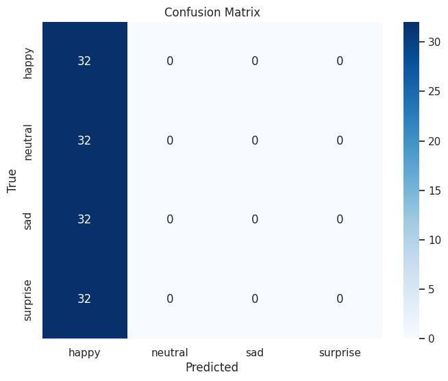

```python
# Evaluating the VGG16-based model on the test data
# This step calculates the model's performance metrics on unseen test data
test_loss, test_accuracy = vgg_model.evaluate(
    test_gen_rgb,                                 # Test data generator for RGB images
    steps=test_gen_rgb.samples // test_gen_rgb.batch_size,  # Number of test batches
    verbose=1                                    # Display evaluation progress
)

# Displaying the test loss and accuracy
print(f"Test Loss: {test_loss:.4f}")             # Printing the test loss rounded to 4 decimal places
print(f"Test Accuracy: {test_accuracy * 100:.2f}%")  # Printing test accuracy as a percentage

# Importing libraries for further evaluation
import numpy as np
from sklearn.metrics import classification_report, confusion_matrix

# Resetting the test generator to ensure alignment between test data and predictions
test_gen_rgb.reset()

# Predicting class probabilities for the test data
predictions = vgg_model.predict(
    test_gen_rgb,                                # Test data generator
    steps=test_gen_rgb.samples // test_gen_rgb.batch_size  # Number of test batches
)

# Converting predicted probabilities to class indices
predicted_classes = np.argmax(predictions, axis=1)

# Extracting the true class labels from the test generator
true_classes = test_gen_rgb.classes

# Retrieving class labels (emotion categories)
class_labels = list(test_gen_rgb.class_indices.keys())

# Printing the classification report for detailed performance metrics
print("Classification Report:")
print(classification_report(true_classes, predicted_classes, target_names=class_labels))

# Importing libraries for confusion matrix visualization
import seaborn as sns
import matplotlib.pyplot as plt

# Generating the confusion matrix to analyze prediction errors
conf_matrix = confusion_matrix(true_classes, predicted_classes)

# Plotting the confusion matrix as a heatmap
plt.figure(figsize=(8, 6))                        # Setting the figure size
sns.heatmap(conf_matrix, annot=True, fmt='d',    # Displaying counts in each cell
            xticklabels=class_labels,            # Setting class labels for x-axis
            yticklabels=class_labels,            # Setting class labels for y-axis
            cmap="Blues")                        # Using a blue color palette
plt.xlabel("Predicted")                          # Label for x-axis
plt.ylabel("True")                               # Label for y-axis
plt.title("Confusion Matrix")                    # Title of the plot
plt.show()                                       # Displaying the heatmap
```

**Think About It:**

- What do you infer from the general trend in the training performance?
- Is the training accuracy consistently improving?
- Is the validation accuracy also improving similarly?

**Observations and Insights:__**

Looking at the confusion matrix and classification report, the situation becomes even clearer. The model seems to predict “happy” for almost everything and ignores the other emotions entirely. This imbalance makes the precision and recall for the other classes abysmal, and it’s a sign that the model isn’t capturing the nuances of the dataset.

**Note: You can even go back and build your own architecture on top of the VGG16 Transfer layer and see if you can improve the performance**

## **ResNet V2 Model**

```python
# Importing the pre-trained ResNet50V2 model and layers for building a custom architecture
from tensorflow.keras.applications import ResNet50V2
from tensorflow.keras.models import Model
from tensorflow.keras.layers import Flatten, Dense, Dropout

# Loading the ResNet50V2 base model with pre-trained weights from ImageNet
# Excluding the top layers (fully connected layers) to add custom ones later
resnet_base = ResNet50V2(weights='imagenet', include_top=False, input_shape=(224, 224, 3))

# Freezing all the layers in the base model
# This ensures the pre-trained weights are not updated during training
for layer in resnet_base.layers:
    layer.trainable = False
```

```
Downloading data from https://storage.googleapis.com/tensorflow/keras-applications/resnet/resnet50v2_weights_tf_dim_ordering_tf_kernels_notop.h5
94668760/94668760 ━━━━━━━━━━━━━━━━━━━━ 3s 0us/step
```

### **Model Building**

- Import Resnet v2 upto the layer of your choice and add Fully Connected layers on top of it.

```python
# Adding custom layers on top of the ResNet50V2 base model
x = resnet_base.output  # Start from the output of the pre-trained ResNet50V2 model
x = Flatten()(x)  # Flatten the feature maps into a single vector
x = Dense(256, activation='relu')(x)  # Fully connected layer with 256 neurons and ReLU activation
x = Dropout(0.5)(x)  # Dropout for regularization to reduce overfitting
x = Dense(128, activation='relu')(x)  # Another fully connected layer with 128 neurons
x = Dropout(0.5)(x)  # Additional dropout layer for further regularization
output = Dense(4, activation='softmax')(x)  # Output layer for 4 classes using softmax activation

# Creating the final model by combining the ResNet base model with the custom layers
resnet_model = Model(inputs=resnet_base.input, outputs=output)

# Displaying the architecture of the combined model to verify the structure
resnet_model.summary()
```

```
Model: "functional_66"
```

```
┏━━━━━━━━━━━━━━━━━━━━━━━━━━━┳━━━━━━━━━━━━━━━━━━━━━━━━┳━━━━━━━━━━━━━━━━┳━━━━━━━━━━━━━━━━━━━━━━━━┓
┃ Layer (type)              ┃ Output Shape           ┃        Param # ┃ Connected to           ┃
┡━━━━━━━━━━━━━━━━━━━━━━━━━━━╇━━━━━━━━━━━━━━━━━━━━━━━━╇━━━━━━━━━━━━━━━━╇━━━━━━━━━━━━━━━━━━━━━━━━┩
│ input_layer_8             │ (None, 224, 224, 3)    │              0 │ -                      │
│ (InputLayer)              │                        │                │                        │
├───────────────────────────┼────────────────────────┼────────────────┼────────────────────────┤
│ conv1_pad (ZeroPadding2D) │ (None, 230, 230, 3)    │              0 │ input_layer_8[0][0]    │
├───────────────────────────┼────────────────────────┼────────────────┼────────────────────────┤
│ conv1_conv (Conv2D)       │ (None, 112, 112, 64)   │          9,472 │ conv1_pad[0][0]        │
├───────────────────────────┼────────────────────────┼────────────────┼────────────────────────┤
│ pool1_pad (ZeroPadding2D) │ (None, 114, 114, 64)   │              0 │ conv1_conv[0][0]       │
├───────────────────────────┼────────────────────────┼────────────────┼────────────────────────┤
│ pool1_pool (MaxPooling2D) │ (None, 56, 56, 64)     │              0 │ pool1_pad[0][0]        │
├───────────────────────────┼────────────────────────┼────────────────┼────────────────────────┤
│ conv2_block1_preact_bn    │ (None, 56, 56, 64)     │            256 │ pool1_pool[0][0]       │
│ (BatchNormalization)      │                        │                │                        │
├───────────────────────────┼────────────────────────┼────────────────┼────────────────────────┤
│ conv2_block1_preact_relu  │ (None, 56, 56, 64)     │              0 │ conv2_block1_preact_b… │
│ (Activation)              │                        │                │                        │
├───────────────────────────┼────────────────────────┼────────────────┼────────────────────────┤
│ conv2_block1_1_conv       │ (None, 56, 56, 64)     │          4,096 │ conv2_block1_preact_r… │
│ (Conv2D)                  │                        │                │                        │
├───────────────────────────┼────────────────────────┼────────────────┼────────────────────────┤
│ conv2_block1_1_bn         │ (None, 56, 56, 64)     │            256 │ conv2_block1_1_conv[0… │
│ (BatchNormalization)      │                        │                │                        │
├───────────────────────────┼────────────────────────┼────────────────┼────────────────────────┤
│ conv2_block1_1_relu       │ (None, 56, 56, 64)     │              0 │ conv2_block1_1_bn[0][… │
│ (Activation)              │                        │                │                        │
├───────────────────────────┼────────────────────────┼────────────────┼────────────────────────┤
│ conv2_block1_2_pad        │ (None, 58, 58, 64)     │              0 │ conv2_block1_1_relu[0… │
│ (ZeroPadding2D)           │                        │                │                        │
├───────────────────────────┼────────────────────────┼────────────────┼────────────────────────┤
│ conv2_block1_2_conv       │ (None, 56, 56, 64)     │         36,864 │ conv2_block1_2_pad[0]… │
│ (Conv2D)                  │                        │                │                        │
├───────────────────────────┼────────────────────────┼────────────────┼────────────────────────┤
│ conv2_block1_2_bn         │ (None, 56, 56, 64)     │            256 │ conv2_block1_2_conv[0… │
│ (BatchNormalization)      │                        │                │                        │
├───────────────────────────┼────────────────────────┼────────────────┼────────────────────────┤
│ conv2_block1_2_relu       │ (None, 56, 56, 64)     │              0 │ conv2_block1_2_bn[0][… │
│ (Activation)              │                        │                │                        │
```

[output cut: 525 more lines]

```
├───────────────────────────┼────────────────────────┼────────────────┼────────────────────────┤
│ post_relu (Activation)    │ (None, 7, 7, 2048)     │              0 │ post_bn[0][0]          │
├───────────────────────────┼────────────────────────┼────────────────┼────────────────────────┤
│ flatten_8 (Flatten)       │ (None, 100352)         │              0 │ post_relu[0][0]        │
├───────────────────────────┼────────────────────────┼────────────────┼────────────────────────┤
│ dense_22 (Dense)          │ (None, 256)            │     25,690,368 │ flatten_8[0][0]        │
├───────────────────────────┼────────────────────────┼────────────────┼────────────────────────┤
│ dropout_14 (Dropout)      │ (None, 256)            │              0 │ dense_22[0][0]         │
├───────────────────────────┼────────────────────────┼────────────────┼────────────────────────┤
│ dense_23 (Dense)          │ (None, 128)            │         32,896 │ dropout_14[0][0]       │
├───────────────────────────┼────────────────────────┼────────────────┼────────────────────────┤
│ dropout_15 (Dropout)      │ (None, 128)            │              0 │ dense_23[0][0]         │
├───────────────────────────┼────────────────────────┼────────────────┼────────────────────────┤
│ dense_24 (Dense)          │ (None, 4)              │            516 │ dropout_15[0][0]       │
└───────────────────────────┴────────────────────────┴────────────────┴────────────────────────┘
```

```
 Total params: 49,288,580 (188.02 MB)
```

```
 Trainable params: 25,723,780 (98.13 MB)
```

```
 Non-trainable params: 23,564,800 (89.89 MB)
```

### **Compiling and Training the Model**

```python
# Compiling the ResNet50V2-based model
# Using Adam optimizer for adaptive learning, categorical crossentropy for multi-class classification,
# and accuracy as the evaluation metric
resnet_model.compile(
    optimizer='adam',                  # Optimizer for weight updates
    loss='categorical_crossentropy',   # Loss function for multi-class problems
    metrics=['accuracy']               # Metric to track during training
)

# Training the ResNet50V2-based model
# Feeding the model with RGB training data and validating on the validation set
history = resnet_model.fit(
    train_gen_rgb,                          # Training data generator for RGB images
    steps_per_epoch=train_gen_rgb.samples // train_gen_rgb.batch_size,  # Number of training batches per epoch
    validation_data=val_gen_rgb,            # Validation data generator
    validation_steps=val_gen_rgb.samples // val_gen_rgb.batch_size,  # Number of validation batches per epoch
    epochs=10                               # Number of epochs for training
)
```

```
472/472 ━━━━━━━━━━━━━━━━━━━━ 629s 1s/step - accuracy: 0.2766 - loss: 3.7421 - val_accuracy: 0.2766 - val_loss: 1.3416
  1/472 ━━━━━━━━━━━━━━━━━━━━ 7:45 989ms/step - accuracy: 0.2812 - loss: 1.3574
```

```
472/472 ━━━━━━━━━━━━━━━━━━━━ 2s 1ms/step - accuracy: 0.2812 - loss: 1.3574 - val_accuracy: 0.1765 - val_loss: 1.2372
472/472 ━━━━━━━━━━━━━━━━━━━━ 624s 1s/step - accuracy: 0.2713 - loss: 1.3800 - val_accuracy: 0.2893 - val_loss: 1.3355
472/472 ━━━━━━━━━━━━━━━━━━━━ 1s 1ms/step - accuracy: 0.2812 - loss: 1.3781 - val_accuracy: 0.3529 - val_loss: 1.1769
472/472 ━━━━━━━━━━━━━━━━━━━━ 626s 1s/step - accuracy: 0.2763 - loss: 1.3841 - val_accuracy: 0.3982 - val_loss: 1.2886
472/472 ━━━━━━━━━━━━━━━━━━━━ 2s 1ms/step - accuracy: 0.2500 - loss: 1.3844 - val_accuracy: 0.4706 - val_loss: 1.1577
472/472 ━━━━━━━━━━━━━━━━━━━━ 638s 1s/step - accuracy: 0.2658 - loss: 1.3832 - val_accuracy: 0.2464 - val_loss: 1.3708
472/472 ━━━━━━━━━━━━━━━━━━━━ 2s 1ms/step - accuracy: 0.2500 - loss: 1.3836 - val_accuracy: 0.5294 - val_loss: 1.3594
472/472 ━━━━━━━━━━━━━━━━━━━━ 639s 1s/step - accuracy: 0.2625 - loss: 1.3890 - val_accuracy: 0.2308 - val_loss: 1.3738
472/472 ━━━━━━━━━━━━━━━━━━━━ 2s 1ms/step - accuracy: 0.3125 - loss: 1.3890 - val_accuracy: 0.0000e+00 - val_loss: 1.4034
```

### **Evaluating the ResNet Model**

```python
# Evaluate the model on the test set
test_loss, test_accuracy = resnet_model.evaluate(
    test_gen_rgb,
    steps=test_gen_rgb.samples // test_gen_rgb.batch_size
)

print(f"Test Loss: {test_loss:.4f}")
print(f"Test Accuracy: {test_accuracy * 100:.2f}%")
```

```
4/4 ━━━━━━━━━━━━━━━━━━━━ 4s 975ms/step - accuracy: 0.2594 - loss: 1.3952
Test Loss: 1.4092
Test Accuracy: 25.00%
```

**Observations and Insights:__**

**Note: You can even go back and build your own architecture on top of the ResNet Transfer layer and see if you can improve the performance.**

The ResNet50V2 model shows clear signs of underfitting, with consistently low accuracy on both training and validation datasets. This indicates that the model is not capturing the complexity of the data despite leveraging a pre-trained backbone. Even after 10 epochs, the model’s accuracy hovers around 25-30%, and the validation loss remains relatively high, suggesting that freezing all the pre-trained layers may not allow the model to adapt to the specific features of this dataset.

Additionally, the test accuracy at 25% is no better than random guessing for a four-class classification problem. This reflects a failure in effectively transferring the knowledge from the base ResNet50V2 model to this task.

## **EfficientNet Model**

```python
# Importing the pre-trained EfficientNetB0 model and layers for customization
from tensorflow.keras.applications import EfficientNetB0
from tensorflow.keras.models import Model
from tensorflow.keras.layers import Flatten, Dense, Dropout

# Loading the EfficientNetB0 base model with pre-trained weights from ImageNet
# Setting include_top to False to exclude the default fully connected layers
efficient_base = EfficientNetB0(weights='imagenet', include_top=False, input_shape=(224, 224, 3))

# Freezing all layers in the EfficientNetB0 base model
# This ensures that the pre-trained weights are retained and not updated during training
for layer in efficient_base.layers:
    layer.trainable = False
```

```
Downloading data from https://storage.googleapis.com/keras-applications/efficientnetb0_notop.h5
16705208/16705208 ━━━━━━━━━━━━━━━━━━━━ 1s 0us/step
```

### **Model Building**

- Import EfficientNet upto the layer of your choice and add Fully Connected layers on top of it.

```python
# Adding custom layers on top of the EfficientNetB0 base model
x = efficient_base.output  # Starting from the output of the pre-trained EfficientNetB0 model
x = Flatten()(x)  # Flattening the feature maps into a 1D vector for fully connected layers
x = Dense(256, activation='relu')(x)  # Fully connected layer with 256 neurons and ReLU activation
x = Dropout(0.5)(x)  # Dropout layer for regularization to reduce overfitting
x = Dense(128, activation='relu')(x)  # Another fully connected layer with 128 neurons
x = Dropout(0.5)(x)  # Additional dropout for further regularization
output = Dense(4, activation='softmax')(x)  # Output layer with 4 neurons for 4 classes using softmax activation

# Creating the final model by combining the EfficientNetB0 base and custom layers
efficient_model = Model(inputs=efficient_base.input, outputs=output)

# Displaying the model's architecture to verify the structure
efficient_model.summary()
```

```
Model: "functional_67"
```

```
┏━━━━━━━━━━━━━━━━━━━━━━━━━━━┳━━━━━━━━━━━━━━━━━━━━━━━━┳━━━━━━━━━━━━━━━━┳━━━━━━━━━━━━━━━━━━━━━━━━┓
┃ Layer (type)              ┃ Output Shape           ┃        Param # ┃ Connected to           ┃
┡━━━━━━━━━━━━━━━━━━━━━━━━━━━╇━━━━━━━━━━━━━━━━━━━━━━━━╇━━━━━━━━━━━━━━━━╇━━━━━━━━━━━━━━━━━━━━━━━━┩
│ input_layer_9             │ (None, 224, 224, 3)    │              0 │ -                      │
│ (InputLayer)              │                        │                │                        │
├───────────────────────────┼────────────────────────┼────────────────┼────────────────────────┤
│ rescaling (Rescaling)     │ (None, 224, 224, 3)    │              0 │ input_layer_9[0][0]    │
├───────────────────────────┼────────────────────────┼────────────────┼────────────────────────┤
│ normalization             │ (None, 224, 224, 3)    │              7 │ rescaling[0][0]        │
│ (Normalization)           │                        │                │                        │
├───────────────────────────┼────────────────────────┼────────────────┼────────────────────────┤
│ rescaling_1 (Rescaling)   │ (None, 224, 224, 3)    │              0 │ normalization[0][0]    │
├───────────────────────────┼────────────────────────┼────────────────┼────────────────────────┤
│ stem_conv_pad             │ (None, 225, 225, 3)    │              0 │ rescaling_1[0][0]      │
│ (ZeroPadding2D)           │                        │                │                        │
├───────────────────────────┼────────────────────────┼────────────────┼────────────────────────┤
│ stem_conv (Conv2D)        │ (None, 112, 112, 32)   │            864 │ stem_conv_pad[0][0]    │
├───────────────────────────┼────────────────────────┼────────────────┼────────────────────────┤
│ stem_bn                   │ (None, 112, 112, 32)   │            128 │ stem_conv[0][0]        │
│ (BatchNormalization)      │                        │                │                        │
├───────────────────────────┼────────────────────────┼────────────────┼────────────────────────┤
│ stem_activation           │ (None, 112, 112, 32)   │              0 │ stem_bn[0][0]          │
│ (Activation)              │                        │                │                        │
├───────────────────────────┼────────────────────────┼────────────────┼────────────────────────┤
│ block1a_dwconv            │ (None, 112, 112, 32)   │            288 │ stem_activation[0][0]  │
│ (DepthwiseConv2D)         │                        │                │                        │
├───────────────────────────┼────────────────────────┼────────────────┼────────────────────────┤
│ block1a_bn                │ (None, 112, 112, 32)   │            128 │ block1a_dwconv[0][0]   │
│ (BatchNormalization)      │                        │                │                        │
├───────────────────────────┼────────────────────────┼────────────────┼────────────────────────┤
│ block1a_activation        │ (None, 112, 112, 32)   │              0 │ block1a_bn[0][0]       │
│ (Activation)              │                        │                │                        │
├───────────────────────────┼────────────────────────┼────────────────┼────────────────────────┤
│ block1a_se_squeeze        │ (None, 32)             │              0 │ block1a_activation[0]… │
│ (GlobalAveragePooling2D)  │                        │                │                        │
├───────────────────────────┼────────────────────────┼────────────────┼────────────────────────┤
│ block1a_se_reshape        │ (None, 1, 1, 32)       │              0 │ block1a_se_squeeze[0]… │
│ (Reshape)                 │                        │                │                        │
├───────────────────────────┼────────────────────────┼────────────────┼────────────────────────┤
│ block1a_se_reduce         │ (None, 1, 1, 8)        │            264 │ block1a_se_reshape[0]… │
```

[output cut: 661 more lines]

```
│ top_activation            │ (None, 7, 7, 1280)     │              0 │ top_bn[0][0]           │
│ (Activation)              │                        │                │                        │
├───────────────────────────┼────────────────────────┼────────────────┼────────────────────────┤
│ flatten_9 (Flatten)       │ (None, 62720)          │              0 │ top_activation[0][0]   │
├───────────────────────────┼────────────────────────┼────────────────┼────────────────────────┤
│ dense_25 (Dense)          │ (None, 256)            │     16,056,576 │ flatten_9[0][0]        │
├───────────────────────────┼────────────────────────┼────────────────┼────────────────────────┤
│ dropout_16 (Dropout)      │ (None, 256)            │              0 │ dense_25[0][0]         │
├───────────────────────────┼────────────────────────┼────────────────┼────────────────────────┤
│ dense_26 (Dense)          │ (None, 128)            │         32,896 │ dropout_16[0][0]       │
├───────────────────────────┼────────────────────────┼────────────────┼────────────────────────┤
│ dropout_17 (Dropout)      │ (None, 128)            │              0 │ dense_26[0][0]         │
├───────────────────────────┼────────────────────────┼────────────────┼────────────────────────┤
│ dense_27 (Dense)          │ (None, 4)              │            516 │ dropout_17[0][0]       │
└───────────────────────────┴────────────────────────┴────────────────┴────────────────────────┘
```

```
 Total params: 20,139,559 (76.83 MB)
```

```
 Trainable params: 16,089,988 (61.38 MB)
```

```
 Non-trainable params: 4,049,571 (15.45 MB)
```